# Chapter D2 溶接継手

## D2.1 はじめに

航空機、ミサイル、宇宙飛行体の全体構造は、単一の連続したユニットとして製造することはできないため、多くの構造部品を結合する必要がある。特定の材料や構造ユニットのタイプでは、溶接は構造ユニットの結合や接続において重要な役割を果たす。より優れた溶接機や溶接技術の開発、また母材や未溶接材料の強度に悪影響を及ぼすことなく溶接できる新材料の開発に向けて、常に研究が行われている。溶接および溶接設計に関するテーマについては、かなりの厚さの本を書くことができる。この簡潔な章は、この主題への簡単な紹介に過ぎない。

## D2.2 ガス溶接

ガス溶接には、酸素アセチレン溶接と酸素水素溶接の2種類がある。航空機業務におけるガス溶接のほぼすべては酸素アセチレン溶接である。アルミニウム合金を溶接する場合、炎がそれほど高温にならないため、酸素水素炎を好む溶接士もいる。ガス溶接が重要な役割を果たす主な航空機構造ユニットは、溶接鋼管トラス胴体、エンジンマウント、着陸装置、およびプレートや機械加工されたフィッティングのそれらの構造への取り付けである。

## D2.3 溶接継手の実用的設計に関する一般注意事項

鋼製溶接構造の設計者は、以下の一般規則に従うことで、溶接士が良好な継手や接続を得るのを大いに助けることができる。

1. 互いに溶接される部品が等しい厚さである場合、良好な溶接を得ることがはるかに容易になる。2つの溶接部品の厚さ比を3対1未満に保つよう努めるのが一般的な設計慣行である。一部の設計者は、溶接士が薄いシートを焼き切る可能性を排除するために、2対1の比率以内に抑えようとする。
2. 設計者は通常、一般的な実用的な構造継手で溶接される最小厚さを0.035インチと見なす。これは、平均的な溶接士がこれより薄いゲージを焼き切るかなりの危険性があるためである。
3. 一般に、溶接部に引張荷重がかかると弱化効果が生じるため、引張部での溶接は避ける。一部の接続では、溶接部へのすべての引張荷重を避けることが困難な場合があるため、溶接応力を低く抑え、可能であればフィッシュマウス継手またはフィンガーパッチを組み込んで、溶接部の一部をせん断状態にする。
4. 溶接は、管の長さに垂直な平面で管を1周するように行うべきではない。重なり合う管のための標準的なスプライスや継手、および管の端部ソケットフィッティングが開発されており、これらは強度チェックを必要としない。これらは、Fig. D2.1に示すような斜め溶接およびフィッシュマウス溶接である。
5. メンバー内の応力強度の緩やかな変化を確実にするために、すべての重要な溶接継手にはテーパーガセットプレートを組み込む必要がある。これらのガセットは、応力強度を低減することにより、疲労破壊の危険性を軽減する。

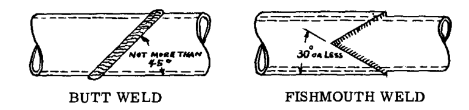

butt weld and fishmouth weld

6. 溶接の上にさらに溶接を重ねて行うべきではない。
7. 薄板の溶接部が焼き切れるのを防ぐため、薄板の両側から溶接を行ってはならない。
8. 2つの溶接部を近づけて配置すると、収縮スペースの不足により亀裂が生じる可能性がある。
9. 曲げ部に溶接を行うと、通常は亀裂が発生する。
10. 溶接によって管をスプライスする場合は、柱の特性に影響を与えるのを避けるため、スプライスを管の端部近くに配置する。一般に、柱部材の中央にブラケットを溶接することは良い習慣ではない。クランプの方が好ましい。
11. 部材を溶接結合する際、局所的な残留応力が発生する。したがって、ほとんどの溶接アセンブリでは、溶接後にアセンブリを「焼きならし（ノーマライズ）」するのが一般的である。この加熱により、局所的な残留応力が均一化され、使用中の亀裂発生を防ぐことができる。
12. 標準的な航空機用ボルトはニッケル鋼で作られており、満足に溶接できないため、溶接して固定すべきではない。標準的な航空機用ナットは1025鋼で作られているため、必要に応じて溶接して固定することができる。

## D2.5 電気アーク溶接

この溶接方法は、電気アークで発生する熱に基づいている。アーク溶接は、航空機製造において長年、限定的に使用されてきた。ガス溶接で得られる柔軟性と全体的な良好な結果が、その広範な使用を遅らせたことは疑いないが、近年、その経済性と利点が設計者に明らかになるにつれて、その使用は急速に増加している。アーク溶接では、加えられる熱がより集中し、ガス溶接と比較して膨張や歪みが少なく、より迅速な溶接結果が得られる。管状継手の設計では、すべての溶接部ができるだけアクセスしやすくなるように注意を払う必要がある。アーク溶接継手において適切な応力分布を確保するために、設計者はFig. D2.15からFig. D2.18に示す推奨事項に従うべきである。

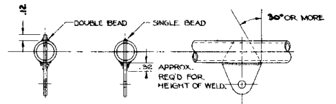

Fig. D2.15

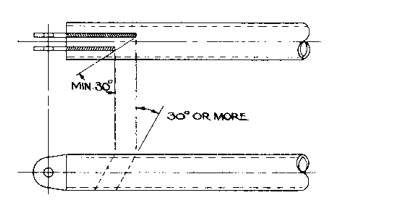

Fig. D2.15 (continued)

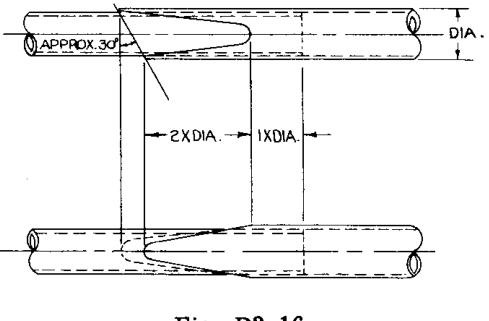

Fig. D2.16

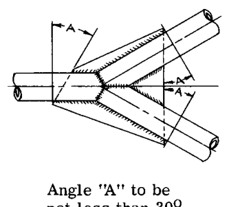

Fig. D2.17

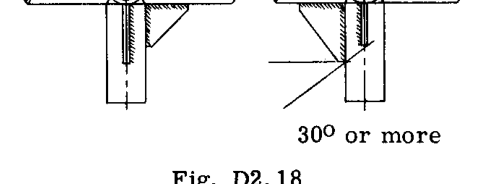

Fig. D2.18

熱が集中するため膨張や歪みが少ないという事実は、溶接後に機械加工を必要とする部品において、より厳しい公差を維持することを可能にする。ほとんどのアセンブリにおいて、1/16インチの取り代で一般に十分である。電気溶接は、最小0.016インチの厚さの薄板の溶接を可能にする。

## D2.6 溶接が母材に及ぼす影響

試験により、普通炭素鋼およびクロムモリブデン鋼は、溶接による引張強度の低下をほとんど受けないことが示されている。冷間圧延されたシートや管の場合、冷間加工による結晶粒の微細化は溶接部に隣接する材料で失われ、強度がわずかに低下する。しかし、溶接は衝撃、振動、応力反転に対する抵抗力が低い、より脆い材料を生み出すため、溶接継手の効率を100パーセント未満と仮定するのが一般的である。

Table D2.1は、熱処理後に構造が溶接される場合の、溶接部に隣接する材料に対する合金鋼の許容極限引張応力を示している。

### Table D2.1 (Ref. 1)

4130、4140、4340、または8630鋼における融接部付近の許容極限引張応力^a  
（セクション厚さ1/4インチ以下）

| 継手のタイプ | 極限引張応力, ksi |
| --- | --- |
| $30^\circ$ 以下のテーパー継手^b | 90 |
| その他すべて | 80 |

^a 溶接後に熱処理、または溶接後に焼きならしされたもの。  
^b 中心線に対して $0^\circ$ テーパーとみなされるガセットまたはプレートインサート。

曲げを受ける溶接部材の場合、熱処理後に溶接された合金鋼の許容破断係数は、(Ref. 1)で指定されているように、以下を超えてはならない。

$30^\circ$ 以下のテーパー継手の場合、 $F_{tu} = 90000\text{ psi}$ の鋼に相当する破断係数 $F_b$ を使用する。

他のすべてのタイプの溶接については、 $F_{tu} = 90000\text{ psi}$ の鋼に対する値の0.9倍に等しい $F_b$ を使用する。Chapter C4は、合金鋼管の破断係数 $F_b$ を決定するためのチャートを提供し、Chapter C3は、曲げを受ける他の形状の $F_b$ を決定する手順を提供している。

### 溶接後に熱処理される場合の母材の強度

文献 (1) によると、溶接後に熱処理される材料の場合、溶接継手付近の母材の許容応力は、熱処理された材料の許容応力と等しくてもよく、すなわち、溶接による低減はない。しかし、溶接継手に対しては控えめに設計することが優れた設計慣行であるため、溶接部に隣接する部材の引張強度または曲げ強度を計算する際には、熱処理後の特性から10%〜20%の低減がしばしば使用される。

### 溶接金属の許容応力

Table D2.2 (Ref. 1 より) は、さまざまな鋼に対する許容溶接金属強度を示している。溶接材料に対するこれらの設計許容応力は、それぞれの最小引張極限試験値の85%に基づいている。

### Table D2.2 (Ref. 1) 溶接継手の強度

| 材料 | 溶接後の熱処理 | $F_{su}$ , ksi | $F_{tu}$ , ksi |
| --- | --- | --- | --- |
| 炭素鋼および合金鋼 | なし | 32 32 | 51 51 |
| 合金鋼 | なし | 43 | 72 |
| 合金鋼 | 応力除去 | 50 | 85 |
| 合金鋼 | 応力除去 | 60 | 100 |
| 鋼 | 焼入れおよび焼戻し |  |  |
| 4130 | 125 ksi | 63 | 105 |
| 4140 | 150 ksi | 75 | 125 |
| 4340 | 180 ksi | 90 | 150 |

## D2.7 溶接シームの許容荷重

溶接シームの許容荷重は、次の式で計算できる。

$$P_a = F_{su} \text{ または } F_{ST} (Lt) \quad \text{--- D2.1}$$

ここで、 * $P_a$ = ポンド単位の許容荷重 * $F_{su}$ および $F_{ST}$ は Table D2.2 からの値 * $L$ = インチ単位の溶接シームの長さ * $t$ = 2枚の鋼板間、またはプレートと管の間の重ね合わせ溶接の場合は、溶接によって結合される最も薄い材料の厚さ（インチ）。 * $t$ = 管アセンブリの場合は溶接金属の平均厚さ（インチ）。ただし、溶接される素材の厚さの1.25倍を超えてはならない。

## D2.8 ろう付け

航空機業務に適用されるろう付けは、空気-ガス炎で溶融するか、または溶融混合物中に浸漬することによって塗布される銅-亜鉛混合物によって鋼製部品を結合するプロセスである。継手の強度は、接触表面積および結合される部品間のクリアランスに依存する。

ろう付け混合物は $40000\text{ psi}$ のせん断強度を発揮することがあるが、多くの要因、特に作業者の技能がろう付け継手の強度に影響するため、航空機業務では $10000\text{ psi}$ の一般的な許容値が使用される。

航空機業務でろう付けを使用する前に、調達機関または政府機関の要件に留意する必要がある。

## D2.9 アルミニウム合金の溶接

2014、2024、7075などの「高強度合金」と一般に呼ばれる熱処理可能な合金は、機械的特性を損なうことなく酸素アセチレン火口で溶接することはできず、これらの特性は溶接後の熱処理によっても回復しない。これらの合金は一般に溶接不可能に分類される。溶接後の強度特性が著しく低下することなく溶接できる、比較的高い強度を持つアルミニウム合金を開発するために、絶えず研究が行われている。Aluminum Company of Americaによる最近の開発は、溶接後に高い強度を発揮するX7005と命名された新合金である。

1100および3003などの加工硬化合金は、ガス溶接によって容易に結合される。酸素アセチレンまたは酸素水素炎のいずれかが使用され、0.020インチほどの薄いシート厚さでも正常に溶接される。航空機用の溶接燃料タンクまたはオイルタンクにこれらの材料を使用することは一般的な慣行である。

## D2.10 溶接に関する例題

### 問題 1

Fig. D2.19 は、重ね継手を形成するために溶接された2枚のプレートを示している。材料は合金鋼で、 $F_{tu} = 95000\text{ psi}$ である。示されているように作用する $5200\text{ lbs.}$ の荷重下における溶接シームの安全余裕（M.S.）を求めよ。

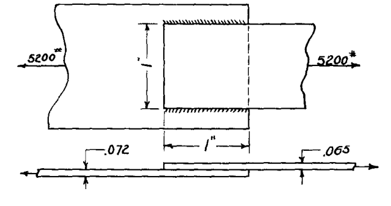

Fig. D2.19

#### 解答

式 D2.1 より、

$$P_a = F_{su} L t$$

Table D2.2より、 $F_{su} = 43000\text{ psi}$ $L$ = 総溶接シーム長さ = $2 \times 1 = 2\text{ in.}$ $t = 0.065\text{ in.}$

$$P_a = 43000 \times 2 \times 0.065 = 5580\text{ lbs.}$$

Table D2.1に従って、溶接による許容応力の低減を考慮し、 $80000\text{ psi}$ を使用した $0.065$ プレートの引張強度は、以下を与える。

$$P_a = 1 \times 0.065 \times 80000 = 5200\text{ lb.}$$

溶接部がプレートを横切って延びていないため、これは控えめな見積もりであり、したがって引張強度特性の低下は上記で想定されたものよりも小さくなるはずである。

### 問題 2

Fig. D2.20 は、トラスの2本の管の端部の間に挿入されたガセットプレートを示している。ガセットは、直径 3/16 インチの鋼製タイロッドからの引っ張り力を受けるフィッティングとして使用される。管へのガセットの接続の安全余裕を決定せよ。材料はすべて鋼で、 $F_{tu} = 95000$ である。

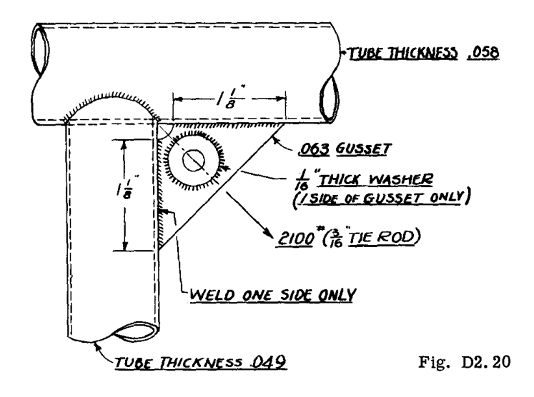

Fig. D2.20

#### 解答

ワイヤの引っ張り力を管に平行な成分に分解すると、次式が得られる。

$$P = 2100 \times \sin 45^\circ = 1480 \times 1.2 \text{
(フィッティング係数)} = 1780\text{ lb.}$$

許容溶接荷重は、最も薄い材料、すなわち垂直管の $0.049$ によって支配される。

$$\begin{aligned}
P_a &= F_{su} L t \\
&= 43000 \times 1.125 \times 0.049 = 2370\text{ lb.}
\end{aligned}$$

$$\text{M.S.} = \frac{2370}{1780} - 1 = 0.33$$

### 問題 3

一般に、プレートと管を含む溶接フィッティングは、継手を通る実際の応力の流れを決定することが困難な条件を提示するため、一般的な手順は、応力流れの分布に関して保守的な仮定を立て、これらの保守的な仮定に対してフィッティングユニットをチェックすることである。次の例は、溶接フィッティング継手の強度チェックのこの近似手順を示している。

Fig. D2.21において、3本の鋼管に溶接されているフィッティングプレートは、示されているように $14000\text{ lb.}$ の引張荷重を受ける。フィッティングに弱点がないか調査する。

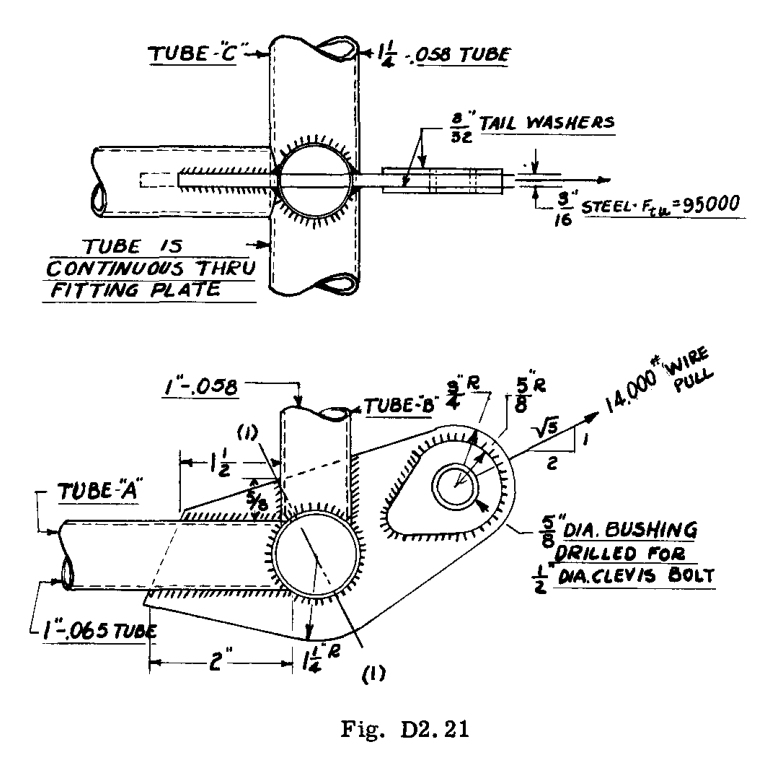

Fig. D2.21

#### 解答

##### クレビスピンのせん断強度:

ピンへの荷重 = $14000\text{ lb.}$

直径 1/2 インチの AN クレビスボルトのダブルせん断強度 = $2 \times 14722 = 29444\text{ lb.}$

$$\text{M.S.} = \frac{29444}{14000} - 1 = 1.1$$

##### ブッシングにおけるクレビスボルトの支圧:

極限支圧応力 = $175000\text{ psi}$ 。したがって、わずかな回転や衝撃による摩耗に対応するために、大きな安全余裕が利用可能である。

##### ラグにおけるブッシングの支圧応力:

$$f_b = \frac{14000}{0.625 \times 0.375} = 59500\text{ psi}$$

許容支圧応力 $F_{br} = 140000\text{ psi}$ (Chapter B2 を参照)。

結果は、ラグの支圧がまったく臨界的ではないことを示している。

##### フィッティングプレートのせん断アウト強度:

$$\begin{aligned}
\text{メインプレートのせん断面積} &= (0.75 - 0.3125) \times 0.1875
\times 2 \\
&= 0.164 \\
\text{ワッシャー} &= (0.625 - 0.3125) \times 0.1875 \times 2 = 0.118
\\
\text{総せん断アウト面積} &= 0.282 \text{ sq.in.}
\end{aligned}$$

$$f_s = \frac{14000}{0.282} = 49700\text{ psi}$$

$F_{tu} = 95000$ の場合の鋼の $F_{su}$ は $55000$ である。Chapter B2 を参照。

この値は、材料特性に対する溶接の影響により $50000$ に低下する。

$$\text{M.S.} = \frac{50000}{49700} - 1 = 0.01$$

せん断アウト面積が保守的であるため、この安全余裕は保守的である。

##### ボルト穴を通る断面の引張応力:

穴を通る断面の面積:

$$f_t = \frac{14000}{0.282} = 49700\text{ psi}$$

溶接の影響を完全に補正した Table D2.1 からの $F_{tu}$ は、 $80000\text{ psi}$ に等しい。

$$\text{M.S.} = \frac{80000}{49700} - 1 = 0.61$$

断面 1-1 におけるフィッティングプレートの引張応力 (Fig. D2.21 を参照)。

$$\text{ネット面積} = (2.5 - 1.25) \times 0.1875 = 0.235 \text{ sq.in.}$$

$14000$ の全荷重がこの断面を通過すると仮定するが、これは間違いなく保守的である。

$$f_t = \frac{14000}{0.235} = 59500\text{ psi}, \quad F_t = 80000\text{
psi. o.k.}$$

##### フィッティングプレートと管の間の接続のチェック:

ワイヤの引っ張り力の水平成分は、管とフィッティングプレートの間の溶接によって管 (A) に伝達されると仮定する。これは保守的な仮定である。

$$\text{水平荷重成分} = 14000 \times \frac{2}{\sqrt{5}} = 12500\text{ lb.}$$

管 (A) とフィッティングプレートの間の溶接長さは、上部管表面で 1.5 インチ、下部表面で 2 インチである。安全側に見積もるため、合計溶接長さは $2 \times 1.5 = 3\text{ インチ}$ が作用していると仮定する。

フィッティングプレートは管の両側で溶接されており、管の厚さの2倍の $0.065$ はプレートの厚さよりも薄いため、管の強度に基づく合計溶接長さは $2 \times 3 = 6\text{ インチ}$ である。

$$\begin{aligned}
P_a &= F_{su} L t = 50000 \times 6 \times 0.065 = 19500\text{ lb.}
\\
\text{M.S.} &= \frac{19500}{12500} - 1 = 0.56
\end{aligned}$$

ワイヤの引っ張り力の垂直成分は、管の各側面に沿った溶接によって管 (B) に伝達されると仮定する。

$$\text{荷重} = 14000 \times \frac{1}{\sqrt{5}} = 6250\text{ lb.}$$

管の片側の溶接長さは長さ 0.625 インチ、もう片側は 1 インチである。合計溶接長さは、控えめに見てわずか $2 \times 0.625 = 1.25\text{ インチ}$ と仮定する。

$$P_a = 50000 \times 1.25 \times 2 \times 0.058 = 7250$$

したがって、この保守的な仮定の下でも、垂直成分を管 (B) に伝達するための溶接取り付けは十分に満たされている。

## D2.11 スポット溶接

長年の研究と試験を経て、アルミニウム合金、マグネシウム合金、および耐食鋼のスポット溶接は、飛行体構造の多くの部品やユニットを結合するための信頼できる確立された手法となった。

スポット溶接プロセスは、比較的高い圧力の下で銅または銅合金の電極の間に2枚以上の金属シートをクランプし、電極間に低電圧の電流を所定の間隔で流すことによって達成される。電流は、シートによって設定された抵抗により、局所的に金属を溶融させる強い熱を点「A」（Fig. a を参照）に発生させる。金属が「B」に示されている程度まで溶融するとすぐに、電流の流れの所定の時間が完了し、シートは電極「P」の圧力によって融合される。この圧力はシートの厚さに依存する。

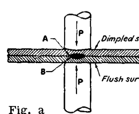

Fig. a

## D2.12 アルミニウム合金のスポット溶接

一般に、アルミニウム合金のスポット溶接継手は、軍事または民間航空当局の特別な承認なしに、一次構造または重要構造に使用すべきではない。以下は、スポット溶接を使用すべきではない航空宇宙構造における構造接続のいくつかのタイプである。

1. 翼の補強されたセルラー構造におけるせん断ウェブへのフランジの取り付け。
2. 翼シート被覆へのせん断ウェブフランジの取り付け。
3. 梁せん断ウェブへの翼リブの取り付け。
4. 支持構造へのヒンジ、ブラケット、およびフィッティングの取り付け。
5. トラス構造の継手部。
6. ストップリベットが使用されない限り、ストリンガーとリブの交点。
7. ストップリベットが使用されない限り、補強材またはストリンガーの端部。
8. ジョグルの各側、または引張荷重成分の可能性がある場所。ただし、ストップリベットが使用されている場合を除く。
9. 一般に、ほとんどのアルミニウムおよびアルミニウム合金の材料の組み合わせはスポット溶接できる。Table D2.3 はこの主題に関する情報を提供している。

### Table D2.3 スポット溶接に許容される材料の組み合わせ

| 材料 | 5052 | 5052 | 6061 | 3003 | Clad 2024 | 1100 | 1100 | Clad 7075^c | Bare 7075^b | Bare 2024^b | Clad 2014 | Bare 2014^b |
| --- | --- | --- | --- | --- | --- | --- | --- | --- | --- | --- | --- | --- |
| 5052 |  |  |  |  |  |  |  |  |  |  |  |  |
| 5052 |  |  |  |  |  |  |  |  |  |  |  |  |
| 6061 |  |  |  |  |  |  |  |  |  |  |  |  |
| 3003 |  |  |  |  |  |  |  |  |  |  |  |  |
| Clad 2024 |  |  |  |  |  |  |  |  |  |  |  |  |
| 1100 |  |  |  |  |  |  |  |  |  |  |  |  |
| 1100 |  |  |  |  |  |  |  |  |  |  |  |  |
| Clad 7075^c |  |  |  |  |  |  |  |  |  |  |  |  |
| Bare 7075^b |  |  |  |  |  |  |  |  | (*) | (*) | (*) | (*) |
| Bare 2024^b |  |  |  |  |  |  |  |  | (*) | (*) | (*) | (*) |
| Clad 2014 |  |  |  |  |  |  |  |  | (*) | (*) |  | (*) |
| Bare 2014^b |  |  |  |  |  |  |  |  | (*) | (*) | (*) | (*) |

^a この表に記載されている様々なアルミニウムおよびアルミニウム合金材料は、表中にアスタリスク (*) で示されている組み合わせを除き、任意の組み合わせでスポット溶接することができる。アスタリスク (*) で示されている組み合わせは、調達機関または認証機関の特別な承認がある場合にのみスポット溶接することができる。  
^b この表は、陸上機および艦載機の製造にのみ適用される。水上飛行機および両用機の製造における、未覆（Bare）の高強度合金の溶接は、調達機関または認証機関によって特に許可されていない限り禁止されている。  
^c 厚さが 0.020 インチ未満のクラッド熱処理・時効処理された 7075 材料は、調達機関または認証機関の特別な承認なしに溶接してはならない。

## D2.13 スポット強度

Fig. D2.22 は、アルミニウム合金においてすべての列で同じピッチを持つスポット溶接継手の最大静的強度と、これらの値を得ることができる最大ピッチを示している。これより大きなピッチを持つ継手については、Table D2.4 を使用する。

Fig. D2.23 は、7075-T6クラッド材料における単一スポット溶接の引張強度を示している。

## D2.14 スポット溶接による母材の引張強度の低下

スポット溶接は、スポット溶接されるシート材料の極限引張強度を低下させる。Fig. D2.24 は、アルミニウム合金シートのスポット溶接における引張効率を示している。

### Table D2.4 (Ref. 1) ベアおよびクラッドアルミニウム合金のせん断強度および最小縁端距離

| 結合される薄い方のシートの公称厚さ、インチ | 56超 | 28〜56 | 20〜27.5 | 19.5以下 | 最小縁端距離、インチ |
| --- | --- | --- | --- | --- | --- |
| 0.012 | 60 | 52 | 24 | 16 | 3/16 |
| 0.016 | 86 | 78 | 56 | 40 | 3/16 |
| 0.020 | 112 | 106 | 80 | 62 | 3/16 |
| 0.025 | 148 | 140 | 116 | 88 | 7/32 |
| 0.032 | 208 | 188 | 168 | 132 | 1/4 |
| 0.040 | 276 | 248 | 240 | 180 | 9/32 |
| 0.051 | 384 | 354 | 329 | 240 | 5/16 |
| 0.064 | 552 | 500 | 451 | 320 | 11/32 |
| 0.072 | 678 | 589 | 524 | 364 | 3/8 |
| 0.081 | 842 | 691 | 620 | 424 | 13/32 |
| 0.091 | 1020 | 810 | 703 | 484 | 7/16 |
| 0.102 | 1230 | 960 | 760 | 548 | 7/16 |
| 0.114 | 1465 | 1085 | 803 | 591 | 7/16 |
| 0.125 | 1698 | 1300 | 840 | 629 | 9/16 |
| 0.156 | 2400 |  |  |  | 5/8 |

### Table D2.5 (Ref. 1) マグネシウム合金のせん断強度

| 薄い方のシートの公称厚さ、インチ | QQ-M-54 | QQ-M-44 | 最小縁端距離、インチ |
| --- | --- | --- | --- |
| 0.020 | 51 | 69 | 3/16 |
| 0.025 | 71 | 97 | 7/32 |
| 0.032 | 102 | 139 | 1/4 |
| 0.040 | 137 | 185 | 9/32 |
| 0.051 | 186 | 251 | 5/16 |
| 0.064 | 242 | 328 | 11/32 |
| 0.072 | 279 | 378 | 3/8 |
| 0.081 | 320 | 434 | 13/32 |
| 0.091 | 368 | 498 | 7/16 |
| 0.102 | 433 | 586 | 7/16 |
| 0.114 | 488 | 658 | 7/16 |
| 0.125 | 544 | 735 | 9/16 |

### Table D2.6 被覆なし鋼^a およびニッケル合金のスポット溶接最大設計せん断強度 (Ref. 1)

| 薄い方のシートの公称厚さ、インチ | 150 ksi以上 | 90 ksi〜150 ksi | 90 ksi未満 |
| --- | --- | --- | --- |
| 0.006 | 70 | 57 |  |
| 0.008 | 120 | 85 | 70 |
| 0.010 | 165 | 127 | 92 |
| 0.012 | 220 | 155 | 120 |
| 0.014 | 270 | 198 | 142 |
| 0.016 | 320 | 235 | 170 |
| 0.018 | 390 | 270 | 198 |
| 0.020 | 425 | 310 | 225 |
| 0.025 | 580 | 425 | 320 |
| 0.030 | 750 | 565 | 403 |
| 0.032 | 835 | 623 | 453 |
| 0.040 | 1,168 | 850 | 650 |
| 0.042 | 1,275 | 920 | 712 |
| 0.050 | 1,700 | 1,205 | 955 |
| 0.056 | 2,039 | 1,358 | 1,166 |
| 0.060 | 2,265 | 1,558 | 1,310 |
| 0.063 | 2,479 | 1,685 | 1,405 |
| 0.071 | 3,012 | 2,024 | 1,656 |
| 0.080 | 3,540 | 2,405 | 1,960 |
| 0.090 | 4,100 | 2,810 | 2,290 |
| 0.095 | 4,336 | 3,012 | 2,476 |
| 0.100 | 4,575 | 3,200 | 2,645 |
| 0.112 | 5,088 | 3,633 | 3,026 |
| 0.125 | 5,665 | 4,052 | 3,440 |

^a 炭素含有量が0.20パーセント以下の普通炭素鋼およびオーステナイト系ステンレス鋼を指す。時間-温度-応力因子の累積的な影響によるスポット溶接強度の低下は、母材の強度の低下より大きくない。

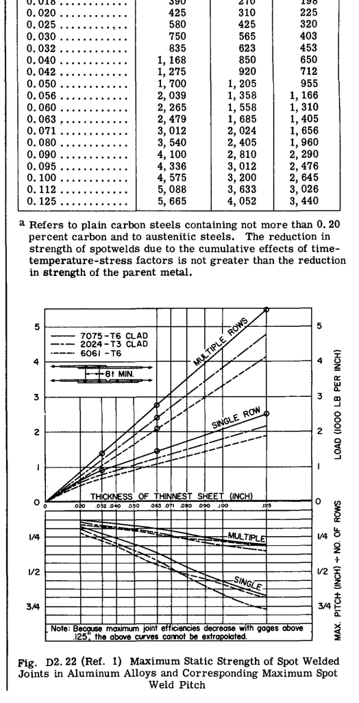

Fig. D2.22

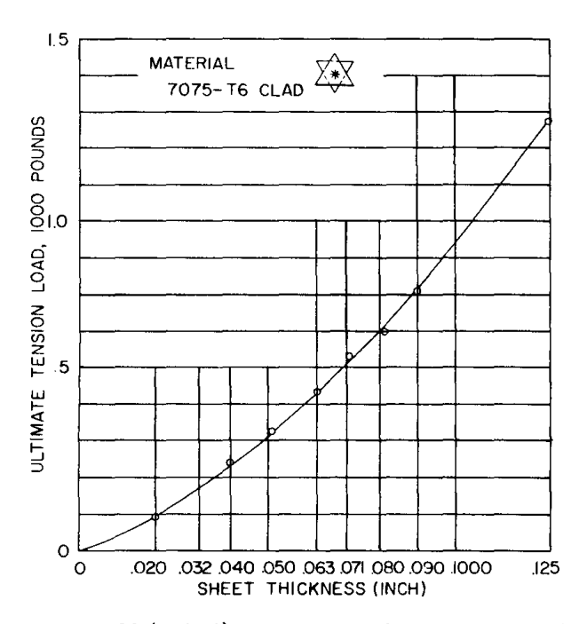

Fig. D2.23

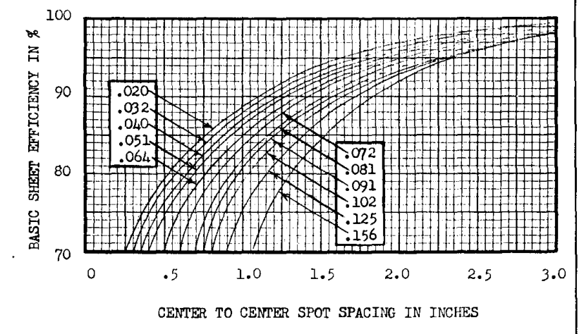

Fig. D2.24

## 問題

1. Fig. Aは、丸い鋼管に固定された溶接プレートフィッティングユニットを示している。フィッティングプレートと管は共に $F_{tu} = 95000$ の鋼である。1.2 のフィッティング係数を使用する場合、フィッティングが受けることができる最大設計荷重 $P$ はいくらか。フィッティングは、ヒンジピン上での振動や回転を受けないものとする。

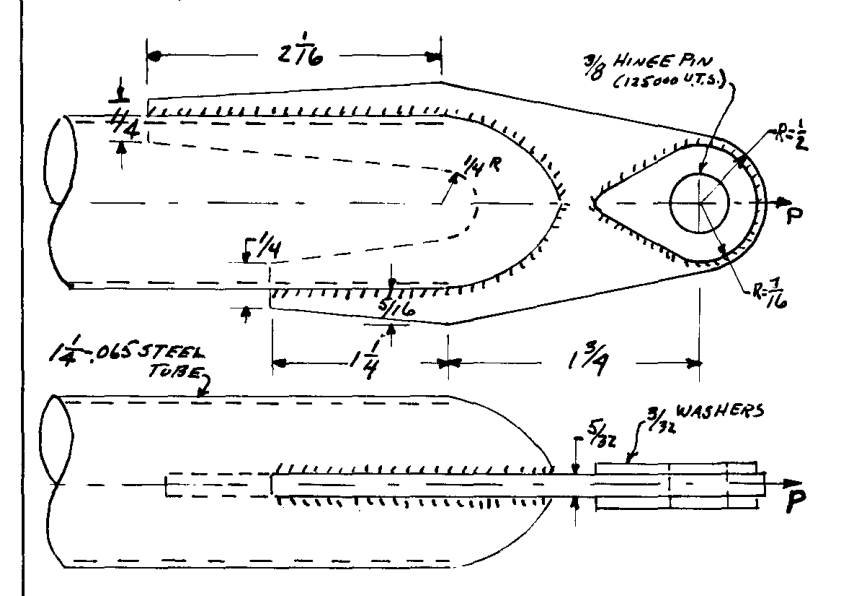

Fig. A

2. 問題1と同様であるが、管とフィッティングは溶接後に $F_{tu} = 150,000$ に熱処理される。
3. 0.051 インチ厚の 2024-T3 アルミニウムシートが、1インチあたり $700\text{ lbs.}$ の極限引張荷重を受ける。これは、0.5 インチ間隔で配置されたスポット溶接の1列を含む重ね継手によってスプライスされている。スポット溶接強度は満足できるか。
4. 7075-T6 アルミニウムシートが $30000\text{ psi}$ の極限引張応力を受ける。シートはスプライスされる予定である。重ね継手用のスポット溶接継手を設計せよ。
5. 外板とストリンガーを含む翼セクションにおいて、特定のストリンガーに隣接するパネルのせん断流は1インチあたり 400 および $600\text{ lbs.}$ であり、同じ方向に作用している。外板の座屈による対角引張作用がないと仮定した場合、外板が 0.04 インチ厚で 2024-T6 アルミニウム合金材料であるとき、ストリンガーを外板に固定するために必要なスポット間隔はいくらか。

## 参考文献

1. Military Handbook - MIL-HDBK-5, August, 1962.
2. ANC-5, March, 1955.